# Capsule 4 - Comparer plusieurs modèles

MQT-2101 - Analyse et modélisation des données

## Pourquoi ça compte

Le modèle le plus souple prédit-il mieux les mois suivants?

Une courbe peut réduire les résidus d’apprentissage sans mieux prédire. Les mêmes mois de validation doivent servir à comparer tous les candidats.

## Objectifs de la capsule

- Séparer apprentissage et validation.
- Calculer et interpréter la RMSE.
- Croiser erreurs, résidus et simplicité.

## Apprendre, comparer, confirmer

Apprendre

ajuster les coefficients sur janvier à septembre

Comparer

prédire octobre à décembre sans réajuster

Confirmer

prévoir de nouvelles données pour évaluer le choix final

Les mois utilisés pour choisir le modèle deviennent un ensemble de validation; ils ne constituent plus un test final indépendant.

## Lire la RMSE

$$\mathrm{RMSE}=\bigl[n^{-1}\sum_{i=1}^{n}(y_i-\widehat{y}_i)^2\bigr]^{1/2}$$

- Racine de la moyenne des erreurs au carré.
- Même unité que la réponse : dollars ici.
- Les grandes erreurs pèsent davantage.

## Un calcul à la main

Erreurs : −2, 1 et 2. Moyenne des carrés : (4 + 1 + 4) / 3 = 3. RMSE = √3 ≈ 1,73.

La moyenne signée vaut 0,33 : ce n’est pas la RMSE.

## Calculer sur les mêmes mois

```r
rmse <- function(observe, predit) {
  sqrt(mean((observe - predit)^2))
}
prediction_quad <- predict(modele_quad, newdata = validation)
rmse(validation$ventes, prediction_quad)
```

```
[1] 7237.256
```

Aucun coefficient n’est réajusté sur les mois de validation.

## Comparer les résultats

Les RMSE sont exprimées en dollars.

| Modèle | R² apprentissage | RMSE apprentissage | RMSE validation |
| --- | --- | --- | --- |
| Linéaire | 0,783 | 8 707 | 10 155 |
| Quadratique | 0,825 | 7 817 | 7 237 |
| Logarithmique | 0,819 | 7 940 | 8 409 |

## Le plus grand R² ne suffit pas

- R² résume l’ajustement sur l’apprentissage.
- Ajouter x² ne peut pas réduire le R² sur les mêmes lignes.
- Le R² ajusté pénalise les paramètres supplémentaires.
- Aucun des deux ne remplace l’erreur de validation.

## Examiner les résidus

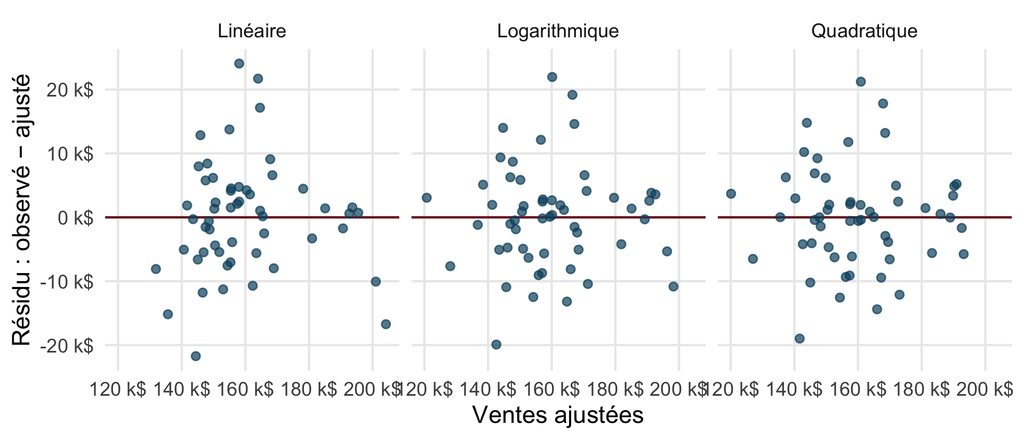

## Un choix provisoire

La quadratique a la plus faible RMSE de validation : 7 237 $, contre 10 155 $ pour la droite.

18 observations seulement, regroupées dans six succursales. Deux achalandages de validation dépassent le maximum d’apprentissage. Le classement peut varier sur une autre période.

## À retenir

Même base

comparaison équitable

Validation

observations non utilisées pour ajuster

Prudence

un classement provisoire

## Production autonome 4.4

Construisez un tableau avec le R² d’apprentissage et les RMSE d’apprentissage et de validation des trois modèles. Proposez un choix provisoire et deux limites.

### Auto-vérification

- Le R² porte sur l’apprentissage.
- La RMSE de validation utilise octobre à décembre.
- Je ne présente pas ce choix comme une performance finale indépendante.